# a3_task3_leonardo_feitosa

Leonardo Feitosa

30/10/2020

## Read in the data

Here, I’ll read in the urchins data.

```r
urchins <- read_csv(here("data","urchins.csv")) %>%
  clean_names()
```

### Section 1

Here, I’ll make the plots for exploratory data analysis.

- Boxplot

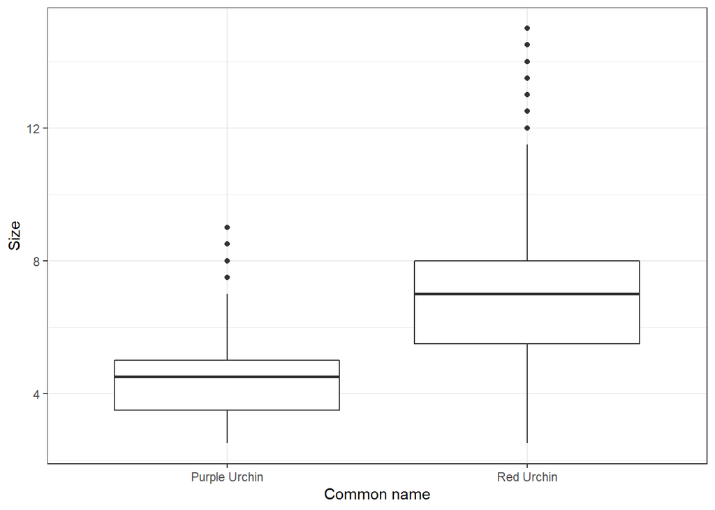

```r
ggplot(urchins, aes(x = common_name, y = size)) +
  geom_boxplot() +
  labs(x = "Common name",
       y = "Size") +
  theme_bw()
```

- Histogram

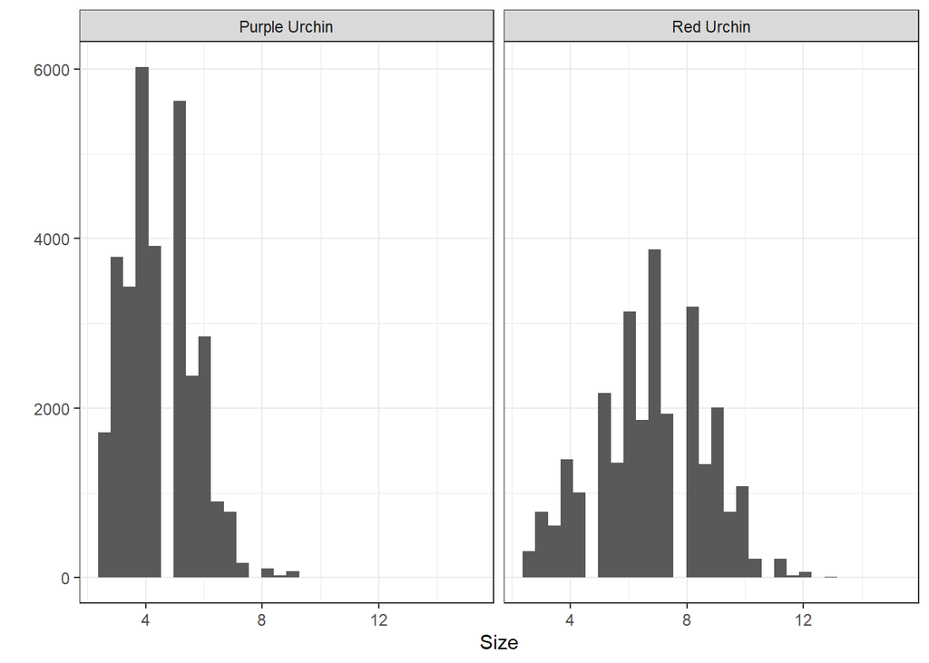

```r
ggplot(urchins, aes(x = size)) +
  geom_histogram()+
  facet_wrap(~ common_name) +
  labs(x = "Size",
       y = "") +
  theme_bw()
```

2 - Descriptive statistics table

Here, I’ll make a descriptive table for the summary statistics with mean, standard deviation (SD), and sample size (n).

```r
urchins_table <- urchins %>%
  group_by(common_name) %>%
  summarise(mean = mean(size),
            sd = sd(size),
            n = n())

urchins_table %>%
  kable(col.names = c("Common name",
                      "Mean",
                      "SD",
                      "N")) %>%
  kable_styling(full_width = F)
```

| Common name | Mean | SD | N |
| --- | --- | --- | --- |
| Purple Urchin | 4.469797 | 1.175264 | 31805 |
| Red Urchin | 6.776489 | 1.891343 | 27408 |

3 - Purple urchins have a mean of 4.469 while red urchins mean size is 6.776. Despite the lowest sample size, the red urchin samples have a higher spread (SD = 1.891) than purple (SD = 1.175), which means that red urchins have a less steep distribution than the purple urchins.

### Section 2

-1 Data wrangling

Here, I’ll do some data wrangling to change the date variable from a character to an actual date. I’ll also create a subset of the data for purple urchins and substitute acronyms for the sites for their complete names.

```r
urchins_clean <- urchins %>%
  mutate(date_new = mdy(date)) %>%
  mutate(year_new = year(date_new))

class(urchins_clean$date_new)
```

```
## [1] "Date"
```

```r
purple_urchins <- urchins_clean %>%
  filter(common_name == "Purple Urchin") %>%
  mutate(site_full = case_when(
    site %in% c("NAPL") ~ "Naples Reef",
    site %in% c("AQUE") ~ "Arroyo Quemado Reef",
    site %in% c("CARP") ~ "Carpinteria Reef",
    site %in% c("MOHK") ~ "Mohawk Reef",
    site %in% c("IVEE") ~ "Isla Vista Reef"
  ))
```

2 - Count data

Here, I’ll make a table with count the number of observations for each year and site

```r
purple_urchins %>%
  select("year_new", "site_full") %>%
  count(site_full, year_new)
```

```
## # A tibble: 61 x 3
##    site_full           year_new     n
##    <chr>                  <dbl> <int>
##  1 Arroyo Quemado Reef     2008    67
##  2 Arroyo Quemado Reef     2009   926
##  3 Arroyo Quemado Reef     2010   921
##  4 Arroyo Quemado Reef     2011   887
##  5 Arroyo Quemado Reef     2012   764
##  6 Arroyo Quemado Reef     2013   434
##  7 Arroyo Quemado Reef     2014   410
##  8 Arroyo Quemado Reef     2015   400
##  9 Arroyo Quemado Reef     2016   342
## 10 Arroyo Quemado Reef     2017   406
## # ... with 51 more rows
```

3 - Exploratory graph

Here, I’ll make a facet exploratory plot for each site between 2008 and 2020 with the purple urchins data set.

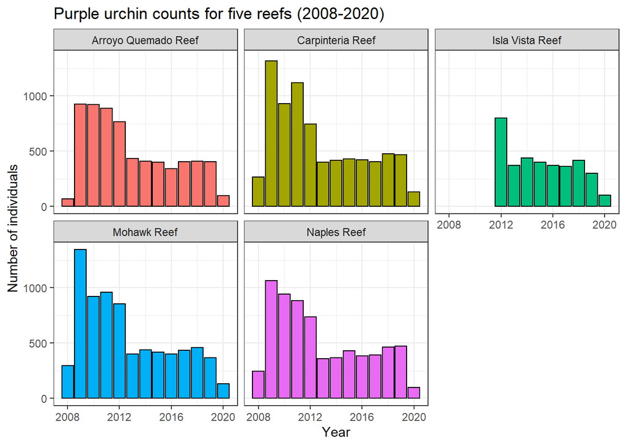

```r
ggplot(purple_urchins, aes(x = year_new, fill = site_full)) +
  geom_bar(color = "black") +
  facet_wrap(~ site_full) +
  labs(x = "Year",
       y = "Number of individuals",
       title = "Purple urchin counts for five reefs (2008-2020)") +
  theme_bw() +
  theme(legend.position = "none")
```